# Hands-on data visualization with ggplot2 - tutorial: basics

## Introduction

```r
library(ggplot2)

#another useful packages
library(RColorBrewer)


#make plots nicer
# R-Ladies ggplot2 theme from Samantha Tyner

r_ladies_theme <- function(base_size){
  theme_bw(base_size) %+replace%
    theme(axis.text = element_text(colour = "#181818"),
          axis.title = element_text(face = "bold", colour = "#88398A", size = rel(1.1)),
          plot.title = element_text(face = "bold", size = rel(1.4),
                                    colour = "#88398A",
                                    margin = margin(t = 0, r = 0, b = 6.6,
                                                    l = 0, unit = "pt")),
          legend.title = element_text(face = "bold", colour = "#181818"),
          panel.grid.major = element_line(color = "#D3D3D3"))
}

theme_set(r_ladies_theme(base_size = 9))
```

Welcome to your first steps in data visualization using [Hardley Wickhams package ggplot2](http://ggplot2.org). Browse the linked website for further in detail information.

At this place we’re going to focus how to code the five basic plots types in R and to understand the grammar of ggplot2. We’re using the ggplot2 integrated dataset [diamonds](http://docs.ggplot2.org/0.9.3.1/diamonds.html).

Corresponding tutorial slides are stored in our [GitHub repo](https://github.com/rladies/meetup-presentations_berlin).

## Dataset: diamonds

```r
#use the integrated help in R Studio for further information
help(diamonds)
```

```r
#summary() of each variable: five-point statistics (numeric), number of entries per levels (factor)
summary(diamonds)
```

```
##      carat               cut        color        clarity
##  Min.   :0.2000   Fair     : 1610   D: 6775   SI1    :13065
##  1st Qu.:0.4000   Good     : 4906   E: 9797   VS2    :12258
##  Median :0.7000   Very Good:12082   F: 9542   SI2    : 9194
##  Mean   :0.7979   Premium  :13791   G:11292   VS1    : 8171
##  3rd Qu.:1.0400   Ideal    :21551   H: 8304   VVS2   : 5066
##  Max.   :5.0100                     I: 5422   VVS1   : 3655
##                                     J: 2808   (Other): 2531
##      depth           table           price             x
##  Min.   :43.00   Min.   :43.00   Min.   :  326   Min.   : 0.000
##  1st Qu.:61.00   1st Qu.:56.00   1st Qu.:  950   1st Qu.: 4.710
##  Median :61.80   Median :57.00   Median : 2401   Median : 5.700
##  Mean   :61.75   Mean   :57.46   Mean   : 3933   Mean   : 5.731
##  3rd Qu.:62.50   3rd Qu.:59.00   3rd Qu.: 5324   3rd Qu.: 6.540
##  Max.   :79.00   Max.   :95.00   Max.   :18823   Max.   :10.740
##
##        y                z
##  Min.   : 0.000   Min.   : 0.000
##  1st Qu.: 4.720   1st Qu.: 2.910
##  Median : 5.710   Median : 3.530
##  Mean   : 5.735   Mean   : 3.539
##  3rd Qu.: 6.540   3rd Qu.: 4.040
##  Max.   :58.900   Max.   :31.800
##
```

## Basic plots

The grammar of ggplot2 is intuitive and provides an easy start creating attractive graphs. The structure of ggplot2 is explained in more in the tutorial slides.

Basically we have to start with the definition of our dataset and the variables we want to plot (x-axis, y-axis). How the data should be visulalized is defined by geometric objects, shortly geom_xy(), and is added in second step to the definition of our data space.

The package ggplot2 contains a number of geoms - here we get started with: *Scatter plots: geom_point()* Line plots: geom_line() *Bar charts and histograms: geom_bar(), geom_histogram()* Box-plots: geom_boxplot(), stat_boxplot() *Multiple facets of variables: facet_grid(), facet_wrap()

### 1 - Scatter plot

*Scatter plots are used to compare two continouse variables*

#### Carat vs. Price

Plot the relation of carat and price of diamonds. *Carat* is a measure of the weight or mass, equal to 200 mg, of pearls and gemstones.

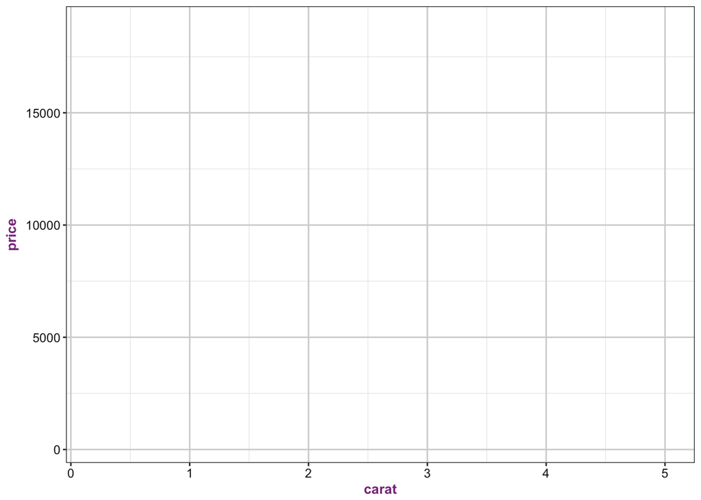

```r
#definition of the data set and variables for each axis.
ggplot(diamonds, aes(x = carat, y = price))
```

But? No graphic! What’s wrong? We have to define how ggplot2 should illustrate our plot by adding a **geom_xy()** (geometric object) of choice.

The **geom_point()** creates a dot for each data point corresponding to the data.

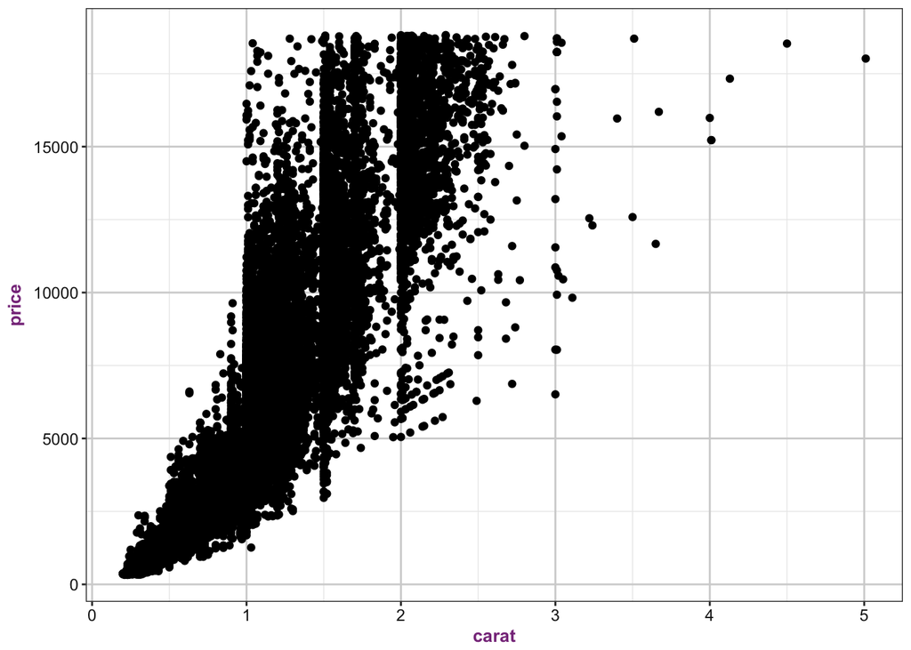

```r
#adding geom_point()
ggplot(diamonds, aes(x = carat, y = price)) +
  geom_point()
```

Here we go! Great, your first scatter plot.

#### Carat vs. Price and colored Cut

Let’s add a third variable to make it more interesting. The *cut* of a diamond affects the quality of a gemstone. How does it look like when we color the dots corresponding to the variable *cut*?

We are modifying the color of each dot. Therefore we have to define an aesthetics for each data point in the **geom_point()** as shown below in the code.

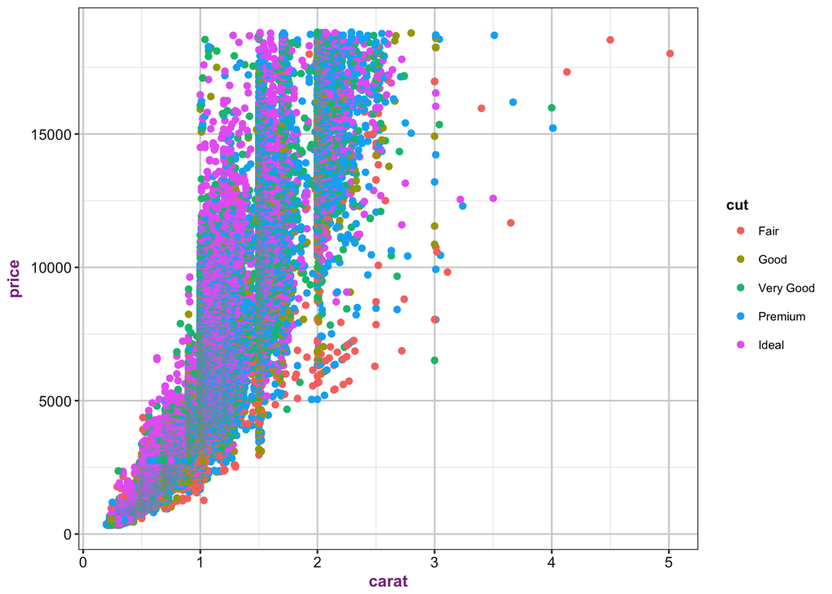

```r
#Color each dot regarding diamonds cut
ggplot(diamonds, aes(x = carat, y = price)) +
  geom_point(aes(color = cut))
```

### 2 - Line plot

*Line plots* are useful for the visulaization of a discrete (x-axis) and a continous (y-axis) variable.

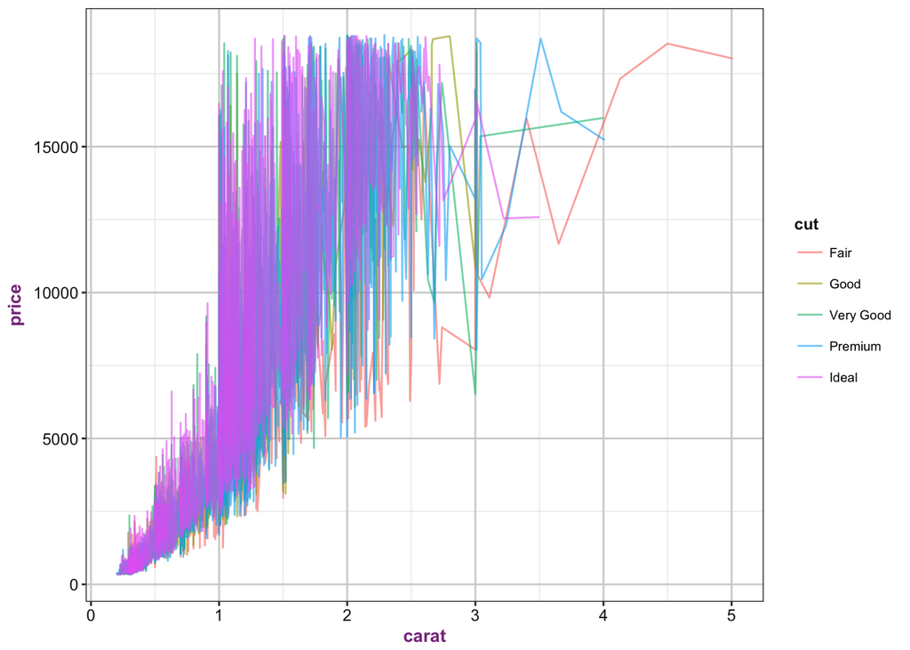

```r
#line plots and alpha (transparency)
ggplot(diamonds, aes(x=carat, y=price, color=cut)) +
    geom_line(alpha=0.6)
```

### 3 - Histograms and bar charts

The bar height reflects either a count of events in each group, or the exact values in a column of the data frame that is plotted. Therefore we only have to specify the variable x in the plot definition.

#### Bar chart

Visualization of counts per catogery. Here an example of the distribution of the number of diamonds per clarity level.

Hint: For the illustration of exact values in a bar plot use *stat = ‘identity’* and add a definition of the y-value in the aesthetics *aes()*.

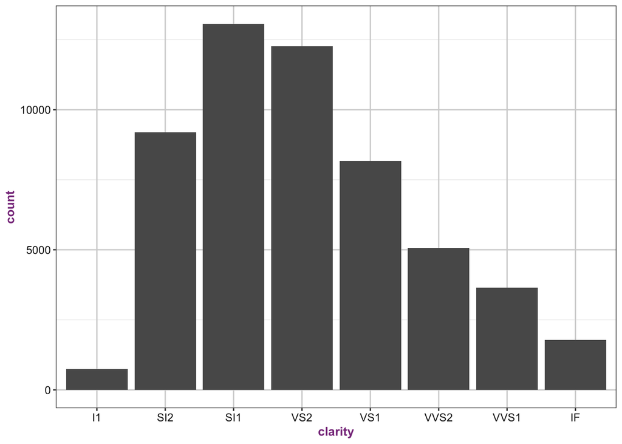

```r
#a simple bar chart
ggplot(diamonds, aes(clarity)) +
    geom_bar()
```

A stacked bar chart showing the distribution of counts in diamond clarity splitted by cut levels. The parameter *fill* can be added either in the plot description or as aesthetics in the geom.

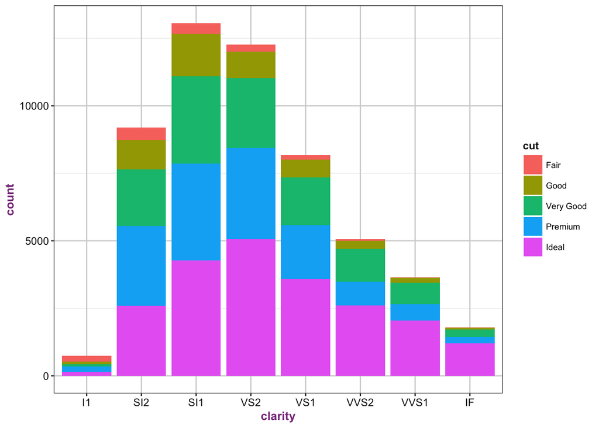

```r
#distinguishing categories in bar charts
ggplot(diamonds, aes(clarity, fill=cut)) +
    geom_bar()
```

```r
#ggplot(diamonds, aes(clarity) +
#   geom_bar(aes(fill = cut))
```

Moving bars of one catogery next to each other by adding *position* parameter. Dodge means: Adjust position by dodging / moving overlaps to the side.

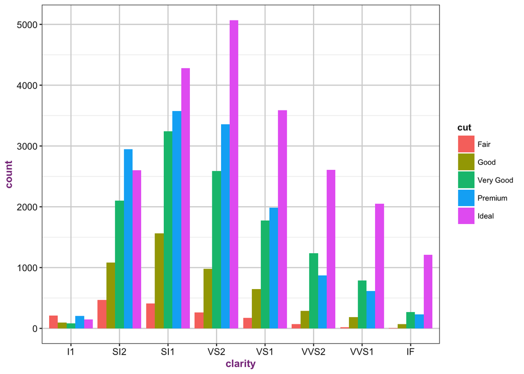

```r
#dodging bar charts next to each other
ggplot(diamonds, aes(clarity, fill=cut)) +
    geom_bar(position="dodge")
```

```r
#creates the same plot
#ggplot(diamonds, aes(clarity, fill=cut)) +
#   geom_bar(position=position_dodge())
```

#### Histogram

important parameter: binwidth, bin

The default is to use bins bins that cover the range of the data. You should always override this value, exploring multiple widths to find the best to illustrate the stories in your data.

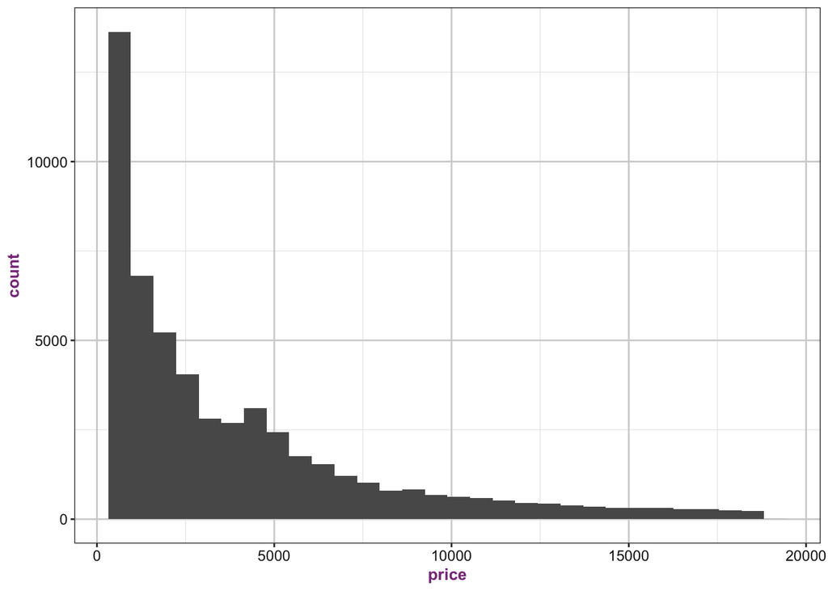

```r
#simple histogram showing the distribution of diamond prices
ggplot(diamonds, aes(price)) +
  geom_histogram()
```

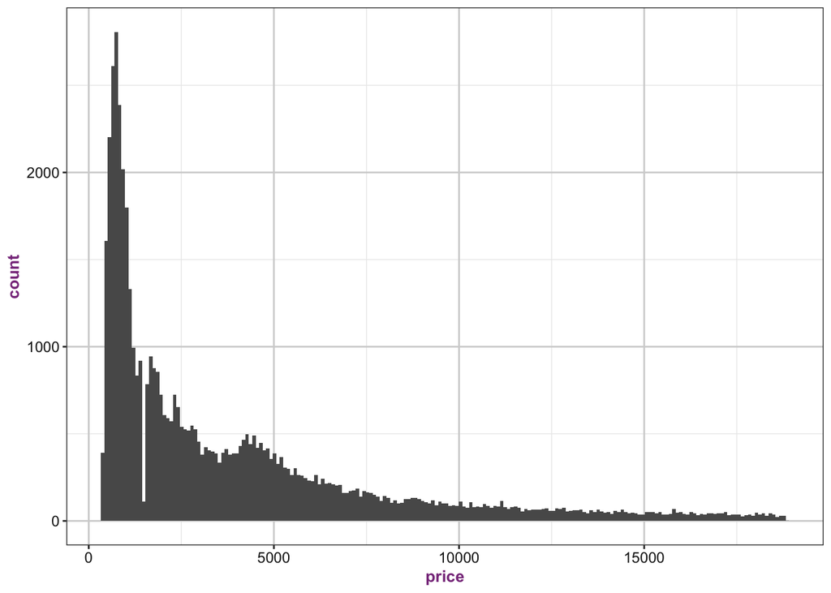

```r
#definition of number of bins
ggplot(diamonds, aes(price)) +
  geom_histogram(bins = 200)
```

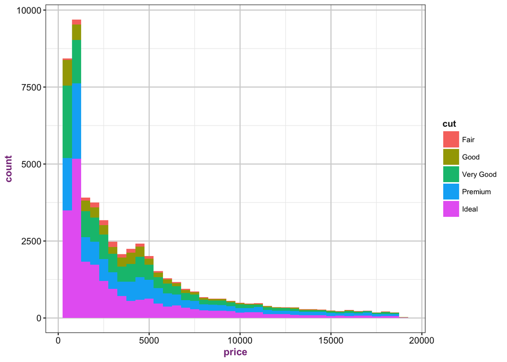

```r
#definition of binwidth
ggplot(diamonds, aes(price, fill = cut)) +
  geom_histogram(binwidth = 500)
```

### 4 - Boxplot

Boxplots are a helpful tool to compare different statistical parameters at one glance.

The upper and lower box ends correspond to the first and third quantiles. The bar inside the box represents the median of the distribution.

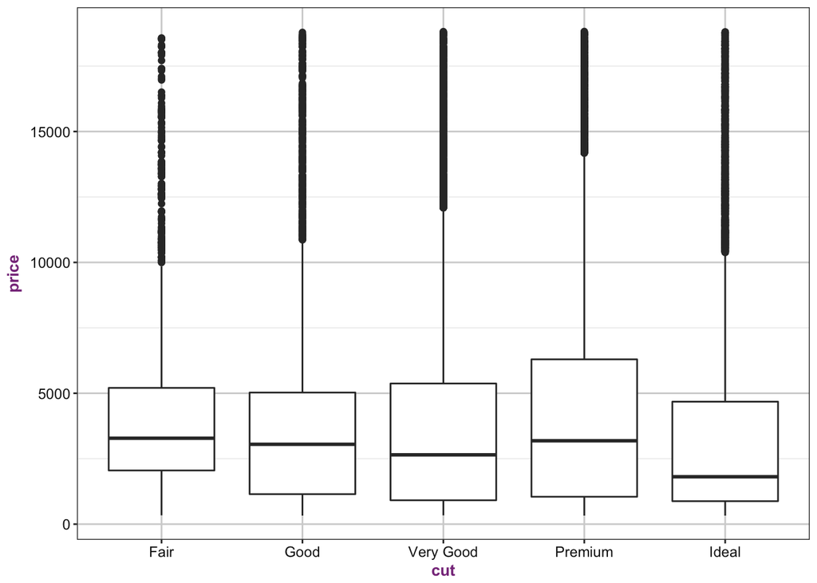

```r
#a simple boxplot helps to compare distributions and related statistics
ggplot(diamonds, aes(x=cut, y=price)) +
    geom_boxplot()
```

How to add whisker? Use the integrated statistics *stat_xy* of **ggplot2**. Statistics calculate and return values based on the graph definition and are directly applied.

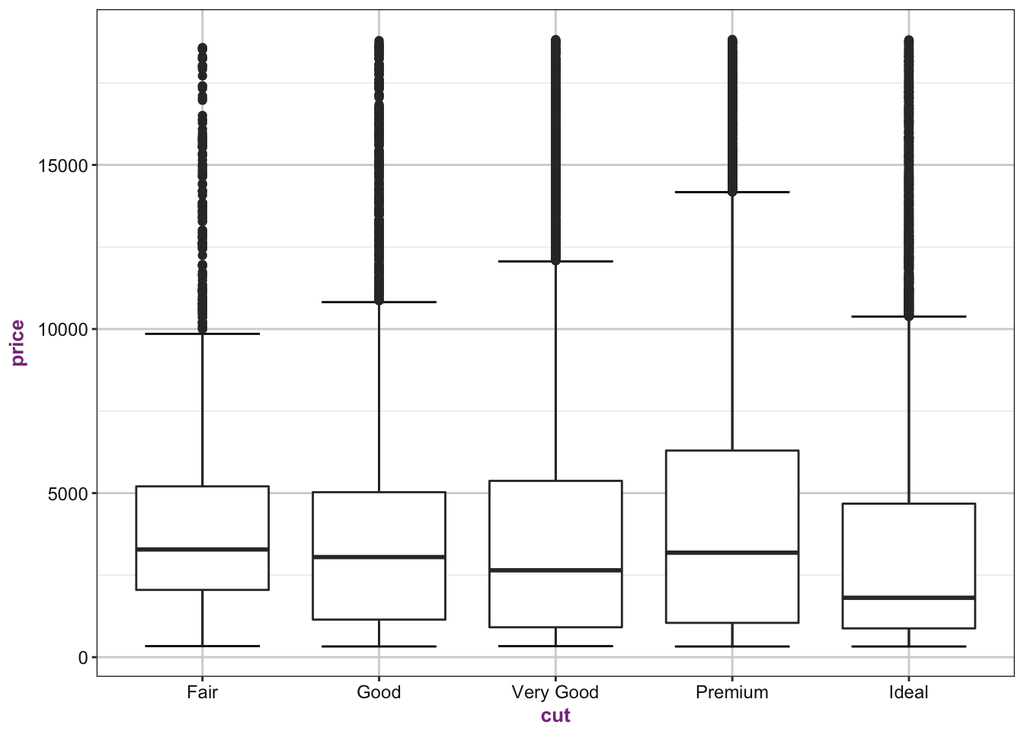

```r
#stat_boxplot for defining whisker
ggplot(diamonds, aes(x = cut, y = price))  +
 stat_boxplot(geom ='errorbar', width = 0.65) +
 geom_boxplot()                 # or: stat_boxplot(geom='boxplot')
```

Also boxplots are distinguishable by another catogery using the *fill* in aesthetics *aes()*.

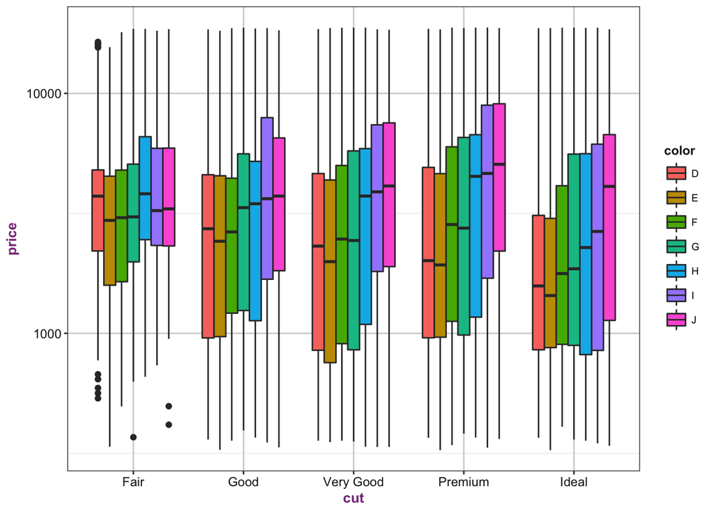

```r
#boxplot grouping prices per color for each cut level, transformation y-axis into log-scale
ggplot(diamonds, aes(x = cut, y = price, fill = color)) +
    geom_boxplot() +
    scale_y_log10()
```

### 5 - Multiple facets

The package **ggplot2** offers two different ways of splitting a complex graph into multiple facets by a single factor or maximum two factors.

*facet_wrap()* arranges the separate facets subsequently next to each other. The number of rows and columns can be defined as additional parameter.

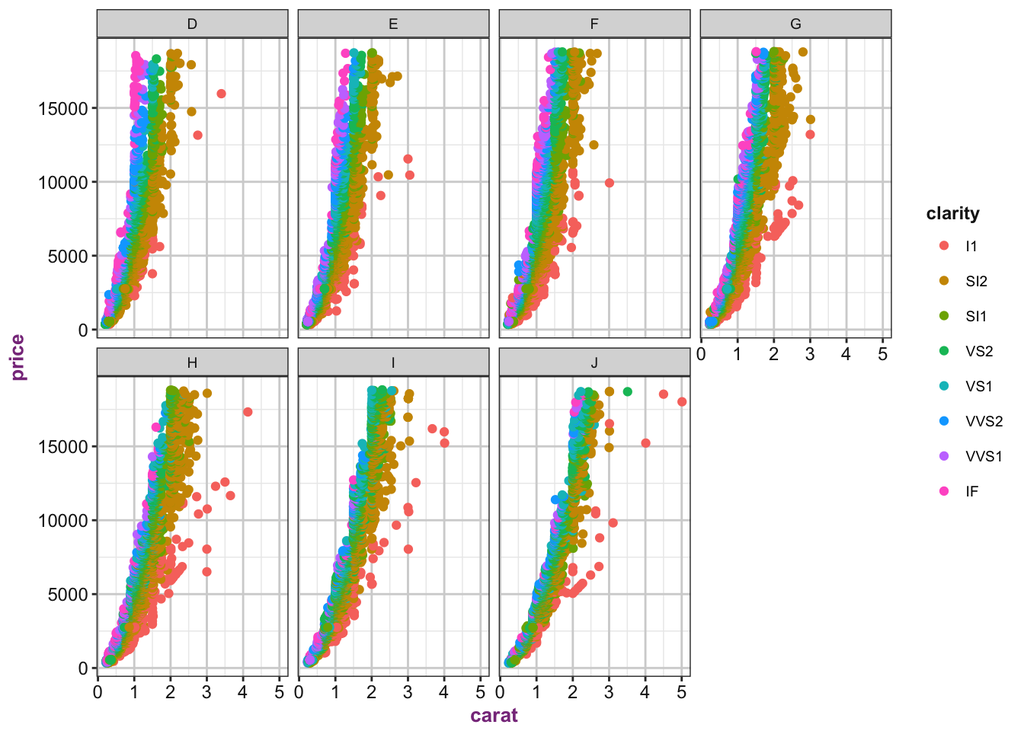

```r
#splitted by color and arranged in the two rows
ggplot(diamonds, aes( x = carat, y = price))+
    geom_point(aes(color = clarity))+
    facet_wrap(~color, nrow = 2)
```

*facet_grid()* creates a matrix-based arrangement of our plots. Dataset factors are separated by the symbol “~”. If there is only a single paramter applied as x coordinate, the second one has to be coded with a placeholder “.”, e.g., + facet_grid(color ~ .).

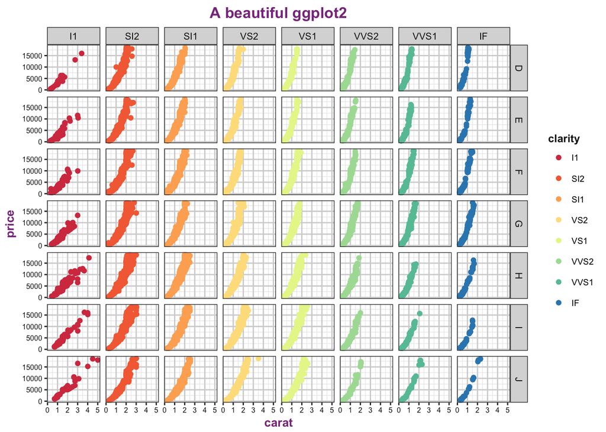

```r
#same plot - more beautiful
ggplot(diamonds, aes(carat, price, color = clarity)) +
    geom_point() +
    facet_grid(color~clarity)+                      #splitted into grid / matrix (x ~ y)
    theme(axis.text = element_text(size = 6),       #modifying grid parameter: smaller text sizees
            strip.text = element_text(size = 8)) +
    scale_color_manual(values = brewer.pal(8, 'Spectral'))+     #changing colors using RColorBrewer
    ggtitle('A beautiful ggplot2')  #plot title
```

## It’s your turn!

### **Task #1:**

Description of the plot:

```
*x-axis: clarity
*y-axis: counts
*grouping: cut (labels right side of graphs)
*color: cut
*additional: plots below each other in one column, splitted by cut
```

```r
#start here
```

### **Task #2:**

Description of the plot:

```
*x-axis: clarity
*y-axis: counts
*grouping: cut (labels right side of graphs)
*color: cut
*additional: bars next to each other per condition
```

```r
#your second trial
```

### **Task #3:**

Description of the plot:

```
*x-axis: price
*y-axis: counts, normalized to 1, stacked
*grouping: cut
*binwidth: 500
```

```r
#the final one
```

## Further information

### Useful commands

Here are summarised the most common commands and parameters of **ggplot2**. Just play with them and see how they are working.

```r
# coord_flip() - rotates your plot theme_bw() - a black and white scheme
# aes(shape = , color = ) - define a variable to this parameter inside aes()
# and modify the shape of points or the color aes(fill = ) - use to
# distinguish a variable in a bar plot, histogram or boxplot
# scale_fill/color_manual() - define your own colors
```

### More examples and help

There are plenty of neat tutorials and nice examples. Our favorites ones are:

- [Cookbook for R](http://www.cookbook-r.com)
- [ggplot2 cheat sheet](https://www.rstudio.com/wp-content/uploads/2015/03/ggplot2-cheatsheet.pdf)
- [stackoverflow](http://stackoverflow.com)